# RTMB Review

Pacific Stock Assessment Renewal

Paul van Dam-Bates

2024-09-24

## Part I: Re-introduction to RTMB

Load in some data.

```r
data(ChickWeight)
```

Consider chick weight data where $w$ = weight, $t$ = time, $k$ = chick (1,…,50), and $D$ = diet (1,2,…, 4).

$$w_i = \beta_0 + \beta_t t_i +
\beta_{D_i}+ \epsilon_i.$$

In this case,

$$\epsilon_i \sim \text{normal}(0,
\sigma^2),$$

where

$$\mu_i = \beta_0 + \beta_t t_i +
\beta_{D_i}.$$

We can code the factor diet in two ways:

1. Levels 2-4 are coded as level 1 (Intercept) + difference.

```r
Design1 <- matrix(0, nrow = nrow(ChickWeight), ncol = 4)
Design1[cbind(1:nrow(ChickWeight), ChickWeight$Diet)] <- 1
Design1[,1] <- 1  ## All observations get Intercept.
Design1 <- cbind(Design1, ChickWeight$Time)
```

2. Each diet gets a different Intercept.

```r
Design2 <- matrix(0, nrow = nrow(ChickWeight), ncol = 4)
Design2[cbind(1:nrow(ChickWeight), ChickWeight$Diet)] <- 1
Design2 <- cbind(Design2, ChickWeight$Time)
```

### Constructing a log-likelihood

- The probability density function for the $i$th observed weight is

$$f(w_i|\mathbf{\theta}) = \text{normal}(\mu_i, \sigma^2)$$

- The likelihood for the $n$ observed data is then the product of the individual densities, $f(\cdot)$,

$$L(\mathbf{\theta}|\mathbf{w}) = \prod_{i=1}^n f(w_i|\mathbf{\theta}).$$
This comes from the fact that if X and Y are independent then $f(X, Y) = f(X)\times f(Y)$. Is this true here?

- We work on the log-scale as probabilities become small and tend to underflow, creating numerical issues. This leads to the sum of the log of each observed density $f$,

$$l(\mathbf{\theta}|\mathbf{w}) = log(L(\mathbf{\theta}|\mathbf{w})) =
\sum_{i=1}^n log(f(w_i|\mathbf{\theta})).$$
Just in case you forgot, $log(A \times B) = log(A) + log(B)$.

- Functions like `optim` or `nlminb` that do optimization in R seek to MINIMIZE the function as a default. For maximum likelihood estimation, we want to find the maximum of the log likelihood, or the minimum of the negative log likelihood.

### Code the negative log-likelihood

Functions like `nlminb` require a single vector to do optimization over that must be the first argument to the function. For this reason, we start with creating a function that has a single vector input.

Note that we generally want our parameters to be unconstrained for optimization. In this case, those are $\boldsymbol{\beta}$ and $\sigma$ (e.g., $\sigma \in (0, \infty) \to log(\sigma) \in (-\infty, \infty)$.

```r
## Parameters are coefficients in the design matrix and variance sigma:
fn <- function(par){
  beta <- par[1:ncol(X)]  ## X is Design Matrix
  sigma <- exp(par[ncol(X)+1])  ## Is this necessary?
  ## Do yourself...
  }
```

```r
fit <- lm(weight ~ Diet + Time, data = ChickWeight)
fit2 <- nlminb(c(rep(0, ncol(Design1)),0), fn)
coef(fit) - fit2$par[1:ncol(Design1)]
```

```
#>   (Intercept)         Diet2         Diet3         Diet4          Time
#>  4.646846e-05  7.071605e-04  1.248335e-03 -1.866777e-03 -4.837374e-06
```

```r
sigma(fit) - exp(fit2$par[ncol(Design1)+1]) ## Why aren't these that close?
```

```
#> [1] 0.1560229
```

```r
biascorrection <- nrow(ChickWeight)/(nrow(ChickWeight)-1)
sigma(fit) - exp(fit2$par[ncol(Design1)+1])*biascorrection ## Better.
```

```
#> [1] 0.093913
```

### Why RTMB?

1. Speed - Makes R run in C++

```r
library(RTMB)
pars <-  c(rep(0, ncol(Design1)),0)
obj <- MakeADFun(fn, pars, silent = TRUE)
microbenchmark::microbenchmark(
    rtmb = obj$fn(pars),
    baseR = fn(pars))
```

```
#> Unit: microseconds
#>   expr    min      lq     mean median     uq   max neval cld
#>   rtmb  5.602  6.0005  8.75504  6.251  7.051 161.5   100  a
#>  baseR 28.002 28.4015 32.86603 28.701 33.101 116.6   100   b
```

2. Automatic Differentiation - Accurate!

```r
## Finite Difference vs AD
gr_true(fit2$par) - pracma::jacobian(obj$fn, fit2$par)
```

```
#>               [,1]          [,2]         [,3]          [,4]          [,5]
#> [1,] -1.021965e-07 -7.144184e-08 5.460247e-08 -2.245381e-08 -2.458391e-07
#>              [,6]
#> [1,] 0.0002510652
```

```r
gr_true(fit2$par) - obj$gr(fit2$par)
```

```
#>              [,1]          [,2]         [,3]         [,4]         [,5]
#> [1,] 1.542549e-16 -7.058156e-17 4.716279e-17 5.076777e-17 9.178422e-15
#>              [,6]
#> [1,] 0.0002510806
```

3. Automatic Differentiation - Fast!

```r
microbenchmark::microbenchmark(
      rtmb = obj$gr(fit2$par),
      baseR = pracma::jacobian(obj$fn, fit2$par))
```

```
#> Unit: microseconds
#>   expr     min       lq      mean  median      uq      max neval cld
#>   rtmb  28.201  39.7005  50.88009  44.701  55.802  140.502   100  a
#>  baseR 213.500 288.3515 318.33194 301.401 309.701 1054.501   100   b
```

### Useful Definitions:

1. Derivative is the rate of change in the function at a single location of the input. For $f(x)$, we know that we are at a maximum or minimum if $\frac{df}{dx} = 0$.
2. If we have multiple variables (vector input), but a single output from the function (scalar), then we have what are called a partial derivatives, describing how things change in each direction, (e.g. $\frac{\partial f}{\partial x_1}$ ).
3. For $N$ inputs, the gradient is the vector of partial derivatives,
   $$\nabla f = \begin{pmatrix}
   \frac{\partial f}{\partial x_1} \\
   \vdots \\
   \frac{\partial f}{\partial x_N}
   \end{pmatrix}.$$
4. If the response has multiple outputs $f_1, \ldots f_K$, then the matrix of all gradients is referred to as the Jacobian $\mathbf{J}$,

$$\mathbf{J} = (\nabla f_1, \ldots, \nabla
f_K).$$

5. For a likelihood, we will only ever have a single output, and so generally minimize the gradient, but that is specific version of a Jacobian.
6. Key piece of theory for transformations: if $\mathbf{y} = g(\mathbf{x})$, then using transformation of variables,
   $$f_y(\mathbf{y}) = f_x(g^{-1}(\mathbf{y}))
   |\mathbf{J}_{g^{-1}(\mathbf{y})}|$$
   Example: lognormal distribution: Normal Distribution:
   $$f(x) =
   \frac{1}{\sqrt{2\pi}\sigma}\text{exp}\Big(-\frac{(x-\mu)^2}{2\sigma^2}\Big)$$
   Then if we want $y = exp(x)$, then $J = \frac{d \text{log}(y)}{d y}$ and the density becomes,
   $$f(y) =
   \frac{1}{\sqrt{2\pi}\sigma
   y}\text{exp}\Big(-\frac{(log(y)-\mu)^2}{2\sigma^2}\Big)$$

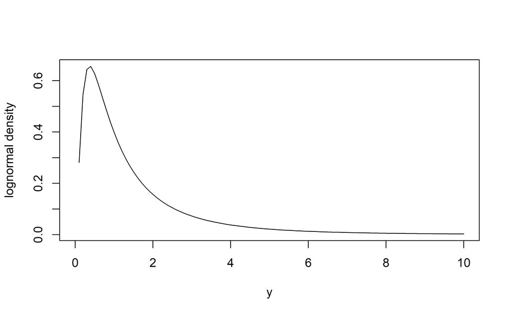

```r
## Log transform
logtransform <- MakeTape(function(x){return(log(x))}, 0) ## go from (0, inf) -> (-inf, inf)
dlognorm <- function(x, mean, sigma){
  ans <- NULL
  for( i in seq_along(x) ) {
    ans <- c(ans,
      dnorm(logtransform(x[i]), mean, sigma)*det(logtransform$jacobian(x[i])))
  }
  return(ans)
}
y <- seq(0, 10, by = 0.1)
plot(y, dlognorm(x=y, 0, 1), xlab = "y", ylab = "lognormal density", type = 'l')
```

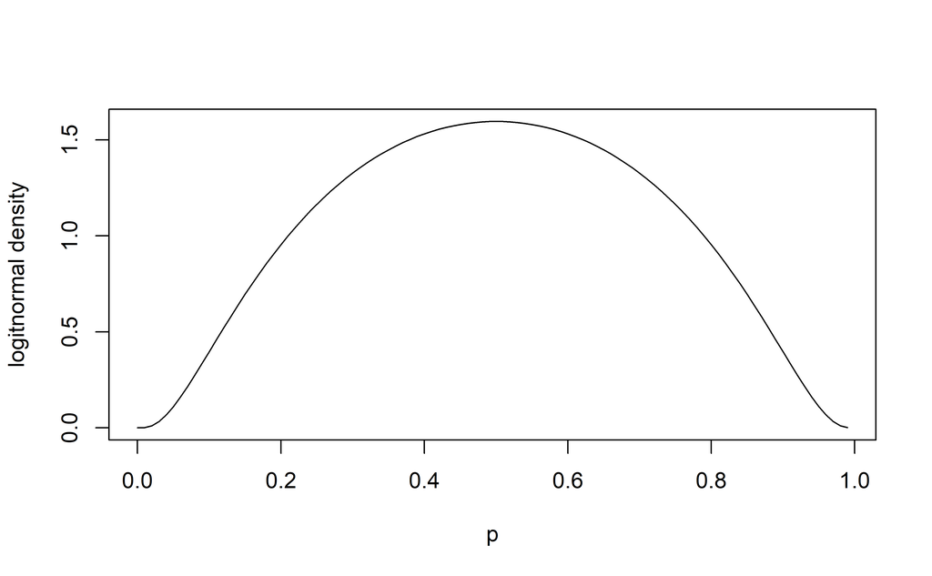

```r
## Logit Transform
logittransform <- MakeTape(function(x){return(log(x/(1-x)))}, 0) ## go from (0,1) -> (-inf, inf)
dlogitnorm <- function(x, mean, sigma){
  ans <- NULL
  for( i in seq_along(x)) {
    ans <- c(ans,
      dnorm(logittransform(x[i]), mean,sigma)*
        abs(det(logittransform$jacobian(x[i]))))
  }
  return(ans)
}
p <- seq(0.0001,0.999,0.01)
plot(p, dlogitnorm(x=p, 0, 1), xlab = "p",
  ylab = "logitnormal density", type = 'l')
```

### Why do derviatives matter?

1. Helps us find the maximum/minimum, when the gradient (vector of partial derivatives) is zero.
2. The variance is defined by the inverse of the Hessian (of the negative log likelihood). Hessian is the derivative of the derivative.
3. Finite difference methods are very slow and often inaccurate.
4. Automatic differentiation can be faster than analytically defined gradients due to the building of a tape. The tape is an efficient set of rules for a chain rule where a lot of the algebra is pre-computed as constants (when building the tape).

## The Laplace Approximation

- The Laplace approximation approximately integrates “normal looking” likelihood surfaces by a single point evaluation at the mode.
- Consider the above Chick Weights problem with a random effect per chick.

```r
library(glmmTMB)
fit.glmm <- glmmTMB(weight ~ Diet + Time + (1|Chick), data = ChickWeight)
fixef(fit.glmm)
```

```
#>
#> Conditional model:
#> (Intercept)        Diet2        Diet3        Diet4         Time
#>      11.231       16.218       36.550       30.030        8.718
```

New Log-Likelihood

- Each random-effect, $u_k$ is assumed to be normally distributed with mean 0, and variance $\sigma_{re}^2$.
- The joint distribution for the random-effects of $N$ chicks is then,

$$f(\mathbf{u}|\boldsymbol{\theta}) = \prod_{k=1}^N
f(u_k|\boldsymbol{\theta})$$

- The change in the log-likelihood happens to the expected value of each observation,

$$\mu_i = \beta_0 + \beta_t t_i +
\beta_{D_i} + u_{chick_i}$$

The new likelihood is then

$$L(\boldsymbol{\theta}|\mathbf{w},\mathbf{u}) =
f(\mathbf{u}|\boldsymbol{\theta}) \prod_{i=1}^n f(w_i|u_{chick_i},
\boldsymbol{\theta}).$$

- The log-likelihood is defined as the sum over the log observed densities plus, the sum of the random effect densities,

$$l(\boldsymbol{\theta}|\mathbf{w},\mathbf{u}) =
\sum_{k=1}^N log(f(u_i|\boldsymbol{\theta})) + \sum_{k=i}^n
log(f(w_i|u_{chick_i}, \boldsymbol{\theta})).$$

```r
ChickWeight$chick <- as.integer(as.character(ChickWeight$Chick))
pars.re <- list(beta = rep(0, ncol(Design1)),
                logsigma = 0, logsigmare = 0,
                re = rep(0, max(ChickWeight$chick)))
## Parameters are coefficients in the design matrix and variance sigma:
fn <- function(par){
  getAll(par)
  sigma <- exp(logsigma)
  sigmare <- exp(logsigmare)
  mu <- Design1 %*% beta + re[as.numeric(ChickWeight$Chick)]
  ADREPORT(sigma)
  ADREPORT(sigmare)
  negll <- sum(-dnorm(ChickWeight$weight, mu, sigma, log = TRUE))
  negll <- negll - sum(dnorm(re, 0, sigmare, log = TRUE))
  negll
}
obj <- MakeADFun(fn, parameters=pars.re, silent = TRUE)
fit.re <- nlminb(obj$par, obj$fn, obj$gr)
sdreport(obj)
```

- To actually make inference we need to marginalize out the $N$ unobserved random effects, $\mathbf{u}$.

$$f(\mathbf{w}|\mathbf{\theta}) =
\int_{-\infty}^\infty \cdots \int_{-\infty}^\infty f(\mathbf{w}|
\mathbf{u}, \mathbf{\theta}) f(\mathbf{u} | \mathbf{\theta}) du_{1}
\cdots d_{N}.$$

- This is an N dimensional integral, which in this particular case, can be written as $N$ single dimension integrals as each chick is independent.
- Works well when this likelihood is unimodal (has one maximum) and looks roughly normal locally. The approximation is EXACT when Normally distributed observations and random effects like in this example.
- The Laplace approximation works by creating a Normal distribution that looks kind of like the posterior distribution of the random-effects we are integrating out,

$$f_G(\mathbf{u}|\mathbf{w},
\mathbf{\theta}) \approx
\text{Multivariate-Normal}(\widehat{\mathbf{u}},
H_{\widehat{u}}^{-1}).$$

- Then, evaluated at the mean,

$$f_G(\widehat{\mathbf{u}} | \mathbf{w},
\mathbf{\theta}) =
\frac{det(H_\widehat{u})^{0.5}}{(2\pi)^{N/2}}$$

- The Laplace approximation is then,

$$f(\mathbf{w}|\mathbf{\theta})
\approx f(\mathbf{w}| \mathbf{u}, \mathbf{\theta}) f(\mathbf{u} |
\mathbf{\theta})/ f_G(\widehat{\mathbf{u}} | \mathbf{w},
\mathbf{\theta})$$

- The recipe is for Laplace is then to find $\widehat{\mathbf{u}}$ for some value of $\boldsymbol{\theta}$, and then find the Hessian $H_{\widehat{u}}$ and calculate,

$$l(\boldsymbol{\theta}|\mathbf{w})
\approx \frac{N}{2}log(2\pi) - log(det(H_{\widehat{u}})) +
l(\boldsymbol{\theta}|\mathbf{w},\widehat{\mathbf{u}})$$

- Let’s do it in RTMB now manually.

```r
nre <- max(ChickWeight$chick)
obj.re <- MakeADFun(fn, parameters = pars.re, silent = TRUE,
    map = list(beta = factor(rep(NA, ncol(Design1))),
      logsigma = factor(NA),
      logsigmare = factor(NA)))
fit.re.only <- nlminb(obj.re$par, obj.re$fn, obj.re$gr)

laplace_approx <- -nre*log(2*pi) +
    log(det(obj.re$he(fit.re.only$par))) +   obj.re$fn(fit.re.only$par)

obj.laplace <- MakeADFun(fn, parameters = pars.re,
                          silent = TRUE, random = "re")
obj.laplace$fn(obj.laplace$par) - laplace_approx
obj.laplace$env$last.par[-(1:(ncol(Design1)+2))] - fit.re.only$par
```

```r
fit.laplace <- nlminb(obj.laplace$par, obj.laplace$fn, obj.laplace$gr)
fit.laplace$par[1:ncol(Design1)] - fixef(fit.glmm)[[1]] ## Matched it.
```

[output not shown]

### RTMB practice:

Choose one of:

1. Write a general RTMB function that does Laplace manually.
2. Find an example where you don’t think Laplace will work well.

## Part II: Stock-Recruit Example

- Consider a Ricker stock recruit relationship for salmon, where $R_t$ is recruitment from year $t$ spawners $S_t$,

$$R_t = \alpha S_t e^{-\beta S_t}$$
- As a linear equation,
$$log(R_t/S_t) =
log(\alpha) - \beta S_t$$

- Install `samEst` from https://github.com/Pacific-salmon-assess/samEst/tree/main
- We will use `load("harck.Rda")` from the GitHub page for this section.

### The Basic Linear Model

- Code a linear model for the Harrison Chinook stock-recruitment data using RTMB (assuming Gaussian error structure for log(R/S)).

```r
load("harck")
fit.harck <- glmmTMB(logRS ~ S, data=harck)
summary(fit.harck)
```

```r
fn <- function(par){
  getAll(par, harck)
  beta <- exp(logbeta)
  sigma <- exp(logsigma)

  Expected_logRS <- logalpha - beta*S
  negll <- -sum(dnorm(logRS,
                        mean = Expected_logRS, sd = sigma, log = TRUE))
  ADREPORT(sigma)
  alpha <- exp(logalpha)
  ADREPORT(alpha)
  ADREPORT(beta)
  return(negll)
}

pars <- list(logalpha = 0, logbeta = 0, logsigma = 0)
obj <- MakeADFun(fn, pars, silent = TRUE)
fit <- nlminb(obj$par, obj$fn, obj$gr)
sdrep <- sdreport(obj)  ## All the values
summary(sdrep, "fixed", p.value = TRUE)
summary(sdrep, "report", p.value = TRUE)
```

- Variance for the parameters being optimized can be written based on the Hessian,

$$V(\boldsymbol{\theta}) =
H_\theta^{-1}.$$

- For a single term, $V(log(\alpha)) = V(\boldsymbol{\theta})_{1,1}$.
- Example,

```r
H <- obj$he(fit$par)
V <- solve(H)
sqrt(diag(V)) - summary(sdrep, "fixed")[,2]
```

- What about the transformed variables? RTMB uses the Delta method,

$$V(g(\theta)) \approx \nabla g V(\theta)
\nabla g'$$

```r
grad <- exp(fit$par)
Vg <- t(grad %*% V) %*% grad
sqrt(diag(Vg)) - summary(sdrep, "report")[c("alpha", "beta", "sigma"),2]
```

- By now it should be really clear that if we can write fast code that efficiently returns derivatives, inference is pretty easy.

## RTMB Tricks

### ADjoint and using R functions by providing derivatives manually.

- Classic example: LambertW. Remember that $W(z) = w$ solves
  $$z = w e^w$$
  . This is solved numerically in different programs but not known analytically. It makes more sense to solve the derivative as it is known, instead of building a tape on the numerical method. In this case, we will want the derivative, $\frac{dW(z)}{dz}$. From implicit differentiation (and the chain rule),
  $$1 = \frac{dW(z)}{dz}e^{W(z)} + W(z)e^{W(z)}\frac{dW(z)}{dz}.$$
  As a result,
  $$\frac{dW(z)}{dz} =
  \frac{1}{[1+W(z)]e^W(z)} = \frac{1}{z + e^{W(z)}}$$
  For the example,

```r
## Note we can just use any package function if we can provide the Jacobian.
## In this case, y = w above and x = z. It gets recycled so you don't have to calculate it twice. The dy term is because of the AD reverse rule and needing "d/dx sum( f(x) * dy )"
lamw <- ADjoint(
  function(x){gsl::lambert_W0(x)},
  function(x, y, dy) {dy / (x + exp(y))}
)

F <- MakeTape(lamw, 0.1)
#F(0.1)
#gsl::lambert_W0(0.1)
#F$jacobian(0.1)
#pracma::jacobian(gsl::lambert_W0, 0.1)
```

- Here is another example using the normal distribution.

```r
x <- rnorm(100, 0.25, 0.1)
myneg_dnorm <- function(theta){
  sum(-dnorm(x, theta[1], theta[2], log = TRUE))
}
gr_myneg_dnorm <- function(theta, f, df) {
  deriv <- numeric(2)
  deriv[1] <- -sum(x-theta[1])/theta[2]^2
  deriv[2] <- length(x)/theta[2] - sum((x-theta[1])^2)/theta[2]^3
  df * deriv ## Not sure if I need the df...
}
test <- ADjoint(myneg_dnorm, gr_myneg_dnorm )
grtest <- MakeTape(test, c(0,1))
fad <- MakeTape(myneg_dnorm, c(0,1))
fad$jacobian(c(0,1)) - grtest$jacobian(c(0,1))
```

### Update data without running MakeADFun or MakeTape again.

```r
f <- function(p) {
    getDat <- function(x) {
        .GlobalEnv$mydat
    }
    empty <- advector(rep(0, 0)) ## Important this is empty but ad variable...
    ## Add R function to the AD tape
    y <- DataEval(getDat, empty)
    -sum(dnorm(y, p$mu, p$sd, log=TRUE))
}
mydat <- rnorm(10000, 0, 10)
obj <- MakeADFun(f, list(mu=0, sd=1), silent = TRUE)
fit1 <- nlminb(obj$par, obj$fn, obj$gr)
mydat <- rnorm(10000, 10, 1)
fit2 <- nlminb(obj$par, obj$fn, obj$gr)
fit1$par
fit2$par
```

### What AD doesn’t like

- We can’t condition the likelihood based on an AD variable. For example,

```r
fn <- function(x){
  if(x < 0) -1/2
  else 1/5
}
fnt <- MakeTape(fn, 0.5)
```

### What about uniform distributions?

```r
fn <- function(theta){
  -dunif(theta, 0, 1,log = TRUE)
}
# fnt <- MakeTape(fn, 0.5)
```

- How can I go from uniform random variable to real scale? One way, for $y \sim \mathcal{U}(a,b)$.
  $$x = \text{logit}\{(y-a)/(b-a)\}.$$
  We then transform using a change of variables (the Jacobian),
  $$f(x) = \frac{1}{b-a} \times \Big|\frac{d }{dx}
  (b-a)\text{logit}^{-1}(x) + a\Big|.$$

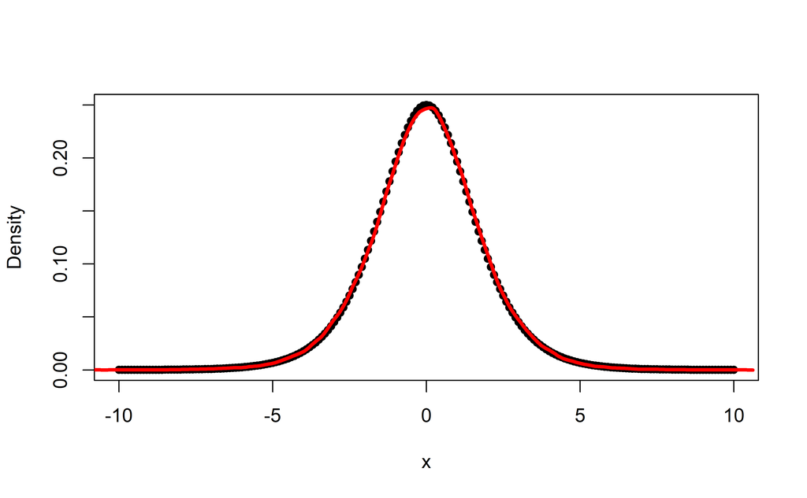

```r
## Make a tape to get a Jacobian.
transilogit <- MakeTape(function(x){1/(1+exp(-x))}, 0)

## What does a uniform prior look like transformed
u <- runif(100000, 0, 1)*0.01
f <- NULL
for( i in seq(-10, 10, by = 0.1)) f <- c(f, 1/0.01*0.01*abs(transilogit$jacobian(i)))
plot(seq(-10, 10, by = 0.1), f, xlab = "x", ylab = "Density", pch = 16)
lines(density(log(u/(0.01)/(1-u/(0.01)))), col = 'red', lwd=3)
```

### Non-numeric argument to mathematical function?

One common error we will see is the Non-numeric argument to mathematical function. This happens when an `advector` is passed to an R function that is not implemented in RTMB.

For example, in RTMB `dgamma` is only implemented for shape and scale (not rate). R uses rate so we need to be explicit about which is which.

```r
func <- function(theta){
  -dgamma(0.35, theta[1], theta[2], log = TRUE)
}
# attempt1 <- MakeTape(func, c(1,1))
func <- function(theta){
  -dgamma(0.35, shape = theta[1], scale = 1/theta[2], log = TRUE)
}
attempt2 <- MakeTape(func, c(1,1))
```

### Understanding the TAPE:

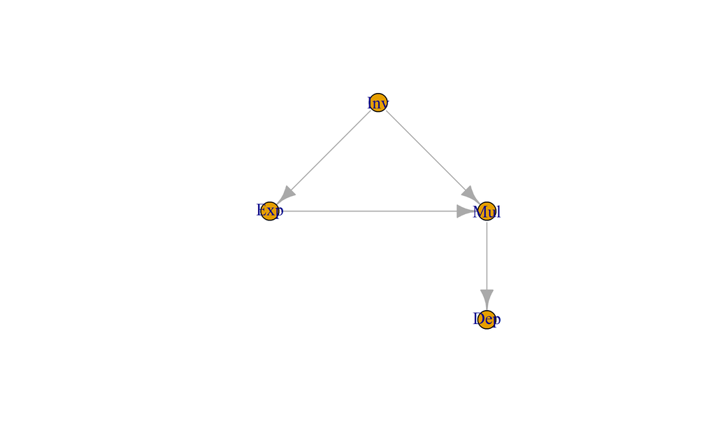

```r
func <- function(theta){
  myvalue <- 0L
  myvalue <- theta
  myvalue <- myvalue * exp(theta)
  myvalue
}
test <- MakeTape(func, 1)
requireNamespace("igraph")
G <- igraph::graph_from_adjacency_matrix(test$graph())
plot(G, vertex.size=17, layout=igraph::layout_as_tree)
```

- If you are building packages in RTMB then you need to make sure that you use `ADoverload` to make sure it tracks types correctly. In this case, `"[<-" <- ADoverload("[<-")` can be placed at the beginning of a function.
- How can you make a function that passes data and parameters?

```r
## Data as explicit argument
nll <- function(parms, y) {
  getAll(parms)
  -sum(dnorm(y, mean = mean, sd = sigma, log = TRUE))
}
cmb <- function(f, d) function(p) f(p, d) ## From Kasper... what does it do???
obj <- RTMB::MakeADFun(cmb(nll, rnorm(100, 1, 4)), list(mean = 0, sigma = 3))
obj$fn()
```

### R package example linear regression

```r
lm_internal <- function(pars){
  "[<-" <- ADoverload("[<-")
  getAll(pars)
  sigma = exp(logsigma)
  mu <- X %*% beta
  ADREPORT(sigma)

  -sum(dnorm(y, mean = mu, sd = sigma, log = TRUE))
}

mylm <- function(formula, data) {
    X <- model.matrix(formula, data)
    pars <- list()
    pars$beta <- rep(0, ncol(X))
    pars$logsigma <- 0

    terms <- terms(formula)
    y <- data[,as.character(terms[[2]])]

    data <- local({X <- X; y <- y; environment()})
    environment(lm_internal) <- data
    obj <- MakeADFun(lm_internal, pars, silent = TRUE)
    opt <- nlminb(obj$par, obj$fn, obj$gr)
    rep <- sdreport(obj)
    return(rep)
}

mylm(weight ~ Time + Diet, data = ChickWeight)
```

### RTMB Practice

- Write an auto regressive process for the `harck` data in RTMB.
- Calculate and generate confidence intervals for maximum sustainable yield ( $S_{msy}$ ) and for the number of spawners needed to return to $S_{msy}$ in one generation, $S_{gen}$.
- Example: https://github.com/Pacific-salmon-assess/samEst/blob/main/R/LamW_RTMB.r